# Basics of linear regression

### Dataset and first model

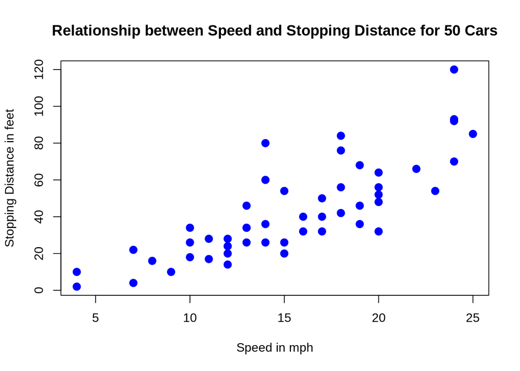

```r
plot(cars, col='blue', pch=20, cex=2,
     main="Relationship between Speed and Stopping Distance for 50 Cars",
     xlab="Speed in mph",
     ylab="Stopping Distance in feet")
```

```r
set.seed(122) # let random numbers be the same every time...
speed.c = scale(cars$speed, center=TRUE, scale=FALSE) # common mith says this improves predictions...
mod1 = lm(formula = dist ~ speed.c, data = cars)   # model distance as linear function of speed
summary(mod1)
```

```
##
## Call:
## lm(formula = dist ~ speed.c, data = cars)
##
## Residuals:
##     Min      1Q  Median      3Q     Max
## -29.069  -9.525  -2.272   9.215  43.201
##
## Coefficients:
##             Estimate Std. Error t value Pr(>|t|)
## (Intercept)  42.9800     2.1750  19.761  < 2e-16 ***
## speed.c       3.9324     0.4155   9.464 1.49e-12 ***
## ---
## Signif. codes:  0 '***' 0.001 '**' 0.01 '*' 0.05 '.' 0.1 ' ' 1
##
## Residual standard error: 15.38 on 48 degrees of freedom
## Multiple R-squared:  0.6511, Adjusted R-squared:  0.6438
## F-statistic: 89.57 on 1 and 48 DF,  p-value: 1.49e-12
```

Check [this article](https://feliperego.github.io/blog/2015/10/23/Interpreting-Model-Output-In-R) for more details.

### Glossary:

1. **residuals**  
   Are differences between actual observation and prediction of the model.  
   Expectation: good model has mean residual close to zero
2. **coefficients**  
   One per column in data. Intercept = free term. Standard error describes uncertainity of every coefficient estimate. Expectation: small Std. error
3. **t-value**  
   How many standard deviations from 0 is this coefficient? Being far from zero suggests existence of a relationship. See *Null Hypothesis*.
4. **Pr(>t) or p-value**  
   Probability that observed value is larger than t-value. A small p-value indicates that it is unlikely we will observe a relationship between the predictor and response due to chance. Expectation: as low as possible, 0.05 being a common cut-off.
5. **Residual Standard error**  
   Is the average amount that the response will deviate from the true regression line.
6. **Multiple R-squared**  
   It always lies between 0 and 1 - it represents what fraction of the observed variance is “explained” by the model. Expectation: a number close to 1.  
   *Warning*: in multiple regression settings, the $R^2$ will always increase as more variables are included in the model. **Adjusted** $R^2$ compensates for that.
7. **F-static**  
   Another indicator of relationship. Obtained by comparing the full model with models obtained from subsets of predictor variables.  
   The further the F-statistic is from 1 the better it is.  
   Generally, when the number of data points is large, an F-statistic that is only a little bit larger than 1 is already sufficient to reject the null hypothesis.